# DL_project slides

## CSE 676: Final Project

## Topic - Twitter Sentiment Analysis

## Author -

## Affan Ali Hasan Khan - 50432243

## Khushal Sharma - 50441869

## jupyter notebook link: https://drive.google.com/file/d/1JsDqNiMu9_KQ60WrPqbDSuzGG4byx6K3/view?usp=share_link

# Abstract

A significant amount of data is generated as well as being made available to internet users thanks to the development and growth of online technologies. The internet has developed into a forum for online education, idea sharing, and opinion exchange. Social networking services like Twitter, Facebook, and Google+ are quickly gaining popularity as a result of the ability for users to share and express their opinions on many subjects, engage in conversation with various communities, and broadcast messages globally.The study of sentiment in Twitter data has received a lot of attention.The major aim of this project is sentiment analysis of twitter data, which is useful for analyzing information in tweets when opinions are very unstructured, varied, and occasionally neutral. In this project, we present a comparative analysis, assessment metrics, and existing methods for opinion mining, such as lexicon-based methods and machine learning methods. We present research on twitter data streams using a variety of machine learning methods, including Bernoulli Naive Bayes, SVM (Support Vector Machine), Logistic Regression, and Neural Network.

# Introduction

# Twitter Sentiment Analysis

Sentiment analysis refers to identifying as well as classifying the sentiments that are expressed in the text source. Tweets are often useful in generating a vast amount of sentiment data upon analysis. These data are useful in understanding the opinion of the people about a variety of topics.

Therefore we need to develop an Automated Machine Learning Sentiment Analysis Model in order to compute the customer perception. Due to the presence of non-useful characters (collectively termed as the noise) along with useful data, it becomes difficult to implement models on them.  
Sentiment analysis is a procedure that uses Natural Language Processing (NLP) to automatically mine attitudes, opinions, perspectives, and emotions from text, audio, tweets, and database sources. In a sentiment analysis, opinions in a text are categorized into "positive" and "negative" categories

# Sentiment Analysis Applications

Customers contact businesses through multiple channels, and it can be hard for teams to stay on top of all this incoming data.

With sentiment analysis tools, however, you can automatically sort your data as and when it filters into your help desk. Let’s take a look at the most popular applications of sentiment analysis:

1) Social media monitoring  
2) Customer support ticket analysis  
3) Brand monitoring and reputation management  
4) Listen to voice of the customer (VoC)  
5) Listen to voice of the employee  
6) Product analysis  
7) Market research and competitive research

# About Dataset

This is the sentiment140 dataset. It contains 1,600,000 tweets extracted using the twitter api . The tweets have been annotated (0 = negative, 4 = positive) and they can be used to detect sentiment .

## Importing Libraries

```python
import re
import numpy as np
import pandas as pd
import nltk
from sklearn.svm import LinearSVC
from sklearn.naive_bayes import BernoulliNB
from sklearn.linear_model import LogisticRegression
from sklearn.model_selection import train_test_split
from sklearn.feature_extraction.text import TfidfVectorizer
from sklearn.metrics import confusion_matrix, classification_report
from nltk.stem import WordNetLemmatizer
import seaborn as sns
from wordcloud import WordCloud
import matplotlib.pyplot as plt
from tensorflow import keras
from tensorflow.keras import layers
from tensorflow.keras.preprocessing.text import Tokenizer
from tensorflow.keras.preprocessing.sequence import pad_sequences
from tensorflow.keras.layers import Input,Conv1D,MaxPooling1D,Dense,GlobalMaxPooling1D,Embedding
from tensorflow.keras.models import Model
```

```python
data_cols=['target','ids','time_date','flag','user','text']
data_encode = "ISO-8859-1"
df = pd.read_csv('training.1600000.processed.noemoticon.csv', encoding=data_encode, names=data_cols)
```

The head function in Python displays the first five rows of the dataframe by default. It takes in a single parameter: the number of rows. We can use this parameter to display the number of rows of our choice.

```python
df.head()
```

|  | target | ids | time_date | flag | user | text |
| --- | --- | --- | --- | --- | --- | --- |
| 0 | 0 | 1467810369 | Mon Apr 06 22:19:45 PDT 2009 | NO_QUERY | _TheSpecialOne_ | @switchfoot http://twitpic.com/2y1zl - Awww, t... |
| 1 | 0 | 1467810672 | Mon Apr 06 22:19:49 PDT 2009 | NO_QUERY | scotthamilton | is upset that he can't update his Facebook by ... |
| 2 | 0 | 1467810917 | Mon Apr 06 22:19:53 PDT 2009 | NO_QUERY | mattycus | @Kenichan I dived many times for the ball. Man... |
| 3 | 0 | 1467811184 | Mon Apr 06 22:19:57 PDT 2009 | NO_QUERY | ElleCTF | my whole body feels itchy and like its on fire |
| 4 | 0 | 1467811193 | Mon Apr 06 22:19:57 PDT 2009 | NO_QUERY | Karoli | @nationwideclass no, it's not behaving at all.... |

# Shape

sentiment140 dataset has 1.6 million rows (tweets) and 6 columns, and they are as follows: 1) target  
2) ids  
3) time_date  
4) flag  
5) user  
6) text

```python
df.shape
```

```
(1600000, 6)
```

```python
df.info()
```

```
<class 'pandas.core.frame.DataFrame'>
RangeIndex: 1600000 entries, 0 to 1599999
Data columns (total 6 columns):
 #   Column     Non-Null Count    Dtype
---  ------     --------------    -----
 0   target     1600000 non-null  int64
 1   ids        1600000 non-null  int64
 2   time_date  1600000 non-null  object
 3   flag       1600000 non-null  object
 4   user       1600000 non-null  object
 5   text       1600000 non-null  object
dtypes: int64(2), object(4)
memory usage: 73.2+ MB
```

# Data Preprocessing

Data preprocessing is the raw data is converted into the understandable format data. The raw data contain missing data, noisy data, and many errors. All the problems will be solved by using data preprocessing techniques. The whole data set is split up into the train and test set. That train set is used to train the machine learning models.

# Raw Data

Raw data is unprocessed computer data. This information may be stored in a file, or may just be a collection of numbers and characters stored on somewhere in the computer’s hard disk. For example, information entered into a database is often called raw data.

The raw data contains a lot of missing data, noisy data and errors, so we cannot use that format in the machine learning models. The preprocessed data only used in the machine learning models.

The better data preprocessing has increased the accuracy of the model. So the data preprocessing is most important in the machine learning and deep learning models.

# Data Preprocessing Techniques

1. Getting the dataset.
2. Importing libraries.
3. Importing dataset.
4. Encoding Categorical Data.
5. Finding Missing Data.
6. Splitting dataset into training and test set.
7. Feature scaling.

# Missing Data

Missing Data can occur when no information is provided for one or more items or for a whole unit. Missing Data is a very big problem in a real-life scenarios. Missing Data can also refer to as NA(Not Available) values in pandas. In DataFrame sometimes many datasets simply arrive with missing data, either because it exists and was not collected or it never existed. However, from this we understand that there are no null values in this dataset.

```python
np.sum(df.isnull().any(axis=1))
```

```
0
```

# Unique Values

```python
df['target'].unique()
```

```
array([0, 4], dtype=int64)
```

# Plot 1

groupBy() function is used to collect the identical data into groups and perform aggregate functions like size/count on the grouped data.Using this bar graph we demostrate that there are equal number of tweets for both negative and positive classification.

```
[Text(0, 0, 'Negative'), Text(1, 0, 'Positive')]
```

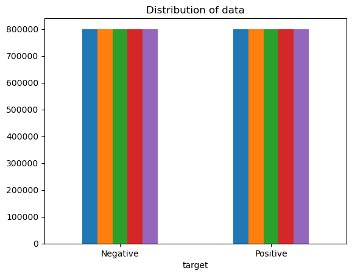

```python
ax = df.groupby('target').count().plot(kind='bar', title='Distribution of data',legend=False)
ax.set_xticklabels(['Negative','Positive'], rotation=0)
```

# Plot 2

A count plot can be thought of as a histogram across a categorical, instead of quantitative, variable. The basic API and options are identical to those for barplot(), so you can compare counts across nested variables. Here we can observe that there are equal number of positive and negative tweets in the dataset.

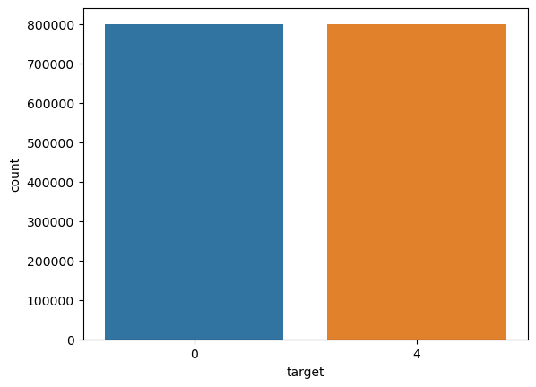

```python
sns.countplot(x='target', data=df)
```

Pandas To Datetime (.to_datetime()) will convert your string representation of a date to an actual date format.

```python
dates=pd.to_datetime(df["time_date"])
```

# Adding 'months' column to dataste

Here, to visualize the data with respect to the month of tweet by the users, we used pandas To Datetime to convert string representation of date to actual date format. Then after storing the values to a column --> 'months' and adding that column to the original daataset we print the dataset as shown below. Now we have 7 columns.

```python
df['months']=pd.DatetimeIndex(dates).month
```

```python
df.head()
```

|  | target | ids | time_date | flag | user | text | months |
| --- | --- | --- | --- | --- | --- | --- | --- |
| 0 | 0 | 1467810369 | Mon Apr 06 22:19:45 PDT 2009 | NO_QUERY | _TheSpecialOne_ | @switchfoot http://twitpic.com/2y1zl - Awww, t... | 4 |
| 1 | 0 | 1467810672 | Mon Apr 06 22:19:49 PDT 2009 | NO_QUERY | scotthamilton | is upset that he can't update his Facebook by ... | 4 |
| 2 | 0 | 1467810917 | Mon Apr 06 22:19:53 PDT 2009 | NO_QUERY | mattycus | @Kenichan I dived many times for the ball. Man... | 4 |
| 3 | 0 | 1467811184 | Mon Apr 06 22:19:57 PDT 2009 | NO_QUERY | ElleCTF | my whole body feels itchy and like its on fire | 4 |
| 4 | 0 | 1467811193 | Mon Apr 06 22:19:57 PDT 2009 | NO_QUERY | Karoli | @nationwideclass no, it's not behaving at all.... | 4 |

# Plot 3

Here we visualize the count of both positive and negative tweets for each month in the dataset by plotting months of diffrent hues to observe that most of the tweets were written on the month of June

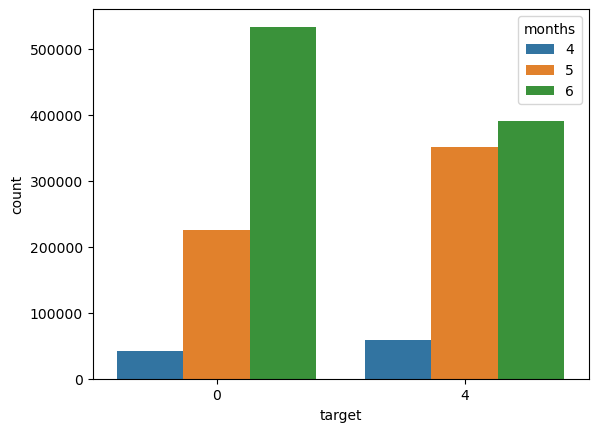

```python
sns.countplot(x='target', hue='months',data=df)
```

The mean() function is used to return the mean of the values for the requested axis. If we apply this method on a Series object, then it returns a scalar value, which is the mean value of all the observations in the dataframe.  
Here, we can see the mean value of month for each category i.e. positive and negative tweet.

```python
df.groupby(['target']).months.mean()
```

```
target
0    5.614955
4    5.414524
Name: months, dtype: float64
```

Replaced all 4 values in target with 1 in order to assign it to positive tweets for simplification.

```python
data=df[['text','target']]
data['target'] = data['target'].replace(4,1)
data['target'].unique()
```

```
array([0, 1], dtype=int64)
```

df.tail( ) - This function returns last n rows from the object based on position. It is useful for quickly verifying data, for example, after sorting or appending rows.

```python
data.tail()
```

|  | text | target |
| --- | --- | --- |
| 1599995 | Just woke up. Having no school is the best fee... | 1 |
| 1599996 | TheWDB.com - Very cool to hear old Walt interv... | 1 |
| 1599997 | Are you ready for your MoJo Makeover? Ask me f... | 1 |
| 1599998 | Happy 38th Birthday to my boo of alll time!!! ... | 1 |
| 1599999 | happy #charitytuesday @theNSPCC @SparksCharity... | 1 |

The iloc() function in python is defined in the Pandas module that helps us to select a specific row or column from the data set. Using the iloc method in python, we can easily retrieve any particular value from a row or column by using index values.

```python
data_pos = data[data['target'] == 1]
data_pos = data_pos.iloc[:int(20000)]
```

```python
data_pos.head()
```

|  | text | target |
| --- | --- | --- |
| 800000 | I LOVE @Health4UandPets u guys r the best!! | 1 |
| 800001 | im meeting up with one of my besties tonight! ... | 1 |
| 800002 | @DaRealSunisaKim Thanks for the Twitter add, S... | 1 |
| 800003 | Being sick can be really cheap when it hurts t... | 1 |
| 800004 | @LovesBrooklyn2 he has that effect on everyone | 1 |

```python
data_neg= data[data['target'] == 0]
data_neg = data_neg.iloc[:int(20000)]
```

```python
data_neg.head()
```

|  | text | target |
| --- | --- | --- |
| 0 | @switchfoot http://twitpic.com/2y1zl - Awww, t... | 0 |
| 1 | is upset that he can't update his Facebook by ... | 0 |
| 2 | @Kenichan I dived many times for the ball. Man... | 0 |
| 3 | my whole body feels itchy and like its on fire | 0 |
| 4 | @nationwideclass no, it's not behaving at all.... | 0 |

```python
joinedtweets=pd.concat([data_pos, data_neg])
```

```python
joinedtweets.head()
```

|  | text | target |
| --- | --- | --- |
| 800000 | I LOVE @Health4UandPets u guys r the best!! | 1 |
| 800001 | im meeting up with one of my besties tonight! ... | 1 |
| 800002 | @DaRealSunisaKim Thanks for the Twitter add, S... | 1 |
| 800003 | Being sick can be really cheap when it hurts t... | 1 |
| 800004 | @LovesBrooklyn2 he has that effect on everyone | 1 |

# Converting text to lower case

```python
joinedtweets['text']=joinedtweets['text'].str.lower()
joinedtweets['text'].tail()
```

```
19995    not much time off this weekend, work trip to m...
19996                            one more day of holidays
19997    feeling so down right now .. i hate you damn h...
19998    geez,i hv to read the whole book of personalit...
19999    i threw my sign at donnie and he bent over to ...
Name: text, dtype: object
```

# Natural Language Toolkit (nltk)

NLTK is a leading platform for building Python programs to work with human language data. It provides easy-to-use interfaces to over 50 corpora and lexical resources such as WordNet, along with a suite of text processing libraries for classification, tokenization, stemming, tagging, parsing, and semantic reasoning, wrappers for industrial-strength NLP libraries, and an active discussion forum.

```python
import nltk
nltk.download('stopwords')
```

```
True
```

# Removing Stop Words

The process of converting data to something a computer can understand is referred to as pre-processing. One of the major forms of pre-processing is to filter out useless data. In natural language processing, useless words (data), are referred to as stop words.

# Stop Words:

A stop word is a commonly used word (such as “the”, “a”, “an”, “in”) that a search engine has been programmed to ignore, both when indexing entries for searching and when retrieving them as the result of a search query. We would not want these words to take up space in our database, or taking up valuable processing time. For this, we can remove them easily, by storing a list of words that you consider to stop words. NLTK(Natural Language Toolkit) in python has a list of stopwords stored in 16 different languages. However, for this dataset we are just concerned for english stop words shown below.

```python
from nltk.corpus import stopwords
stops = stopwords.words('english')
print(stops)
```

[output not shown]

```python
words_list=['a', 'about', 'above', 'after', 'again', 'ain', 'all', 'am', 'an',
             'and','any','are', 'as', 'at', 'be', 'because', 'been', 'before',
             'being', 'below', 'between','both', 'by', 'can', 'd', 'did', 'do',
             'does', 'doing', 'down', 'during', 'each','few', 'for', 'from',
             'further', 'had', 'has', 'have', 'having', 'he', 'her', 'here',
             'hers', 'herself', 'him', 'himself', 'his', 'how', 'i', 'if', 'in',
             'into','is', 'it', 'its', 'itself', 'just', 'll', 'm', 'ma',
             'me', 'more', 'most','my', 'myself', 'now', 'o', 'of', 'on', 'once',
             'only', 'or', 'other', 'our', 'ours','ourselves', 'out', 'own', 're','s', 'same', 'she', "shes", 'should', "shouldve",'so', 'some', 'such',
             't', 'than', 'that', "thatll", 'the', 'their', 'theirs', 'them',
             'themselves', 'then', 'there', 'these', 'they', 'this', 'those',
             'through', 'to', 'too','under', 'until', 'up', 've', 'very', 'was',
             'we', 'were', 'what', 'when', 'where','which','while', 'who', 'whom',
             'why', 'will', 'with', 'won', 'y', 'you', "youd","youll", "youre",
             "youve", 'your', 'yours', 'yourself', 'yourselves']
```

# Combining stop words with word_list

```python
stopwordlist=stops+words_list
STOPWORDS = set(stopwordlist)
```

# Data Preprocessing for tweets

# Cleaning Stop Words

function cleaning_stopwords return a split value of each text from the tweets by iterating over ever word from the tweet. Provided those words are not a stop word.

```python
def cleaning_stopwords(text):
    return " ".join([word for word in str(text).split() if word not in STOPWORDS])
joinedtweets['text'] = joinedtweets['text'].apply(lambda text: cleaning_stopwords(text))
joinedtweets['text'].head()
```

```
800000                love @health4uandpets u guys r best!!
800001    im meeting one besties tonight! cant wait!! - ...
800002    @darealsunisakim thanks twitter add, sunisa! g...
800003    sick really cheap hurts much eat real food plu...
800004                      @lovesbrooklyn2 effect everyone
Name: text, dtype: object
```

# Cleaning punctuations

```python
import string
english_punctuations = string.punctuation
```

```python
def cleaning_punctuations(text):
    translator = str.maketrans('', '', english_punctuations)
    return text.translate(translator)
joinedtweets['text']= joinedtweets['text'].apply(lambda x: cleaning_punctuations(x))
joinedtweets['text'].tail()
```

```
19995    much time weekend work trip malmï¿½ frisat tod...
19996                                     one day holidays
19997                     feeling right  hate damn humprey
19998    geezi hv read whole book personality types emb...
19999     threw sign donnie bent get thingee made sad face
Name: text, dtype: object
```

# Cleaning Repeated Characters

```python
def cleaning_repeating_char(text):
    return re.sub(r'(.)1+', r'1', text)
joinedtweets['text'] = joinedtweets['text'].apply(lambda x: cleaning_repeating_char(x))
joinedtweets['text'].tail()
```

```
19995    much time weekend work trip malmï¿½ frisat tod...
19996                                     one day holidays
19997                     feeling right  hate damn humprey
19998    geezi hv read whole book personality types emb...
19999     threw sign donnie bent get thingee made sad face
Name: text, dtype: object
```

# Cleaning URL

```python
def cleaning_URLs(data):
    return re.sub('((www.[^s]+)|(https?://[^s]+))',' ',data)
joinedtweets['text'] = joinedtweets['text'].apply(lambda x: cleaning_URLs(x))
joinedtweets['text'].tail()
```

```
19995    much time weekend work trip malmï¿½ frisat tod...
19996                                     one day holidays
19997                     feeling right  hate damn humprey
19998    geezi hv read whole book personality types emb...
19999     threw sign donnie bent get thingee made sad face
Name: text, dtype: object
```

# Cleaning Numbers

```python
def cleaning_numbers(data):
    return re.sub('[0-9]+', '', data)
joinedtweets['text'] = joinedtweets['text'].apply(lambda x: cleaning_numbers(x))
joinedtweets['text'].tail()
```

```
19995    much time weekend work trip malmï¿½ frisat tod...
19996                                     one day holidays
19997                     feeling right  hate damn humprey
19998    geezi hv read whole book personality types emb...
19999     threw sign donnie bent get thingee made sad face
Name: text, dtype: object
```

# Tokenizer

With the help of nltk.tokenize.SpaceTokenizer() method, we are able to extract the tokens from string of words on the basis of space between them by using tokenize.SpaceTokenizer() method.

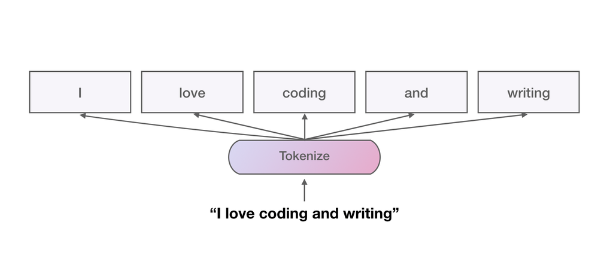

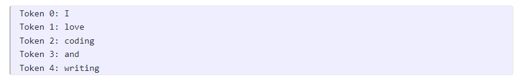

```python
from nltk.tokenize import SpaceTokenizer
tokenizer=SpaceTokenizer()
joinedtweets['text'] = joinedtweets['text'].apply(tokenizer.tokenize)
joinedtweets['text'].head()
```

```
800000             [love, healthuandpets, u, guys, r, best]
800001    [im, meeting, one, besties, tonight, cant, wai...
800002    [darealsunisakim, thanks, twitter, add, sunisa...
800003    [sick, really, cheap, hurts, much, eat, real, ...
800004                    [lovesbrooklyn, effect, everyone]
Name: text, dtype: object
```

# Stemming

Stemming is the process of producing morphological variants of a root/base word. Stemming programs are commonly referred to as stemming algorithms or stemmers. A stemming algorithm reduces the words “chocolates”, “chocolatey”, and “choco” to the root word, “chocolate” and “retrieval”, “retrieved”, “retrieves” reduce to the stem “retrieve”.

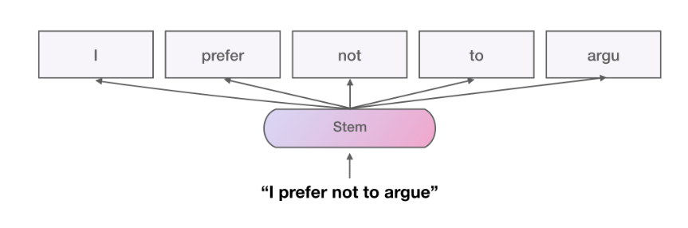

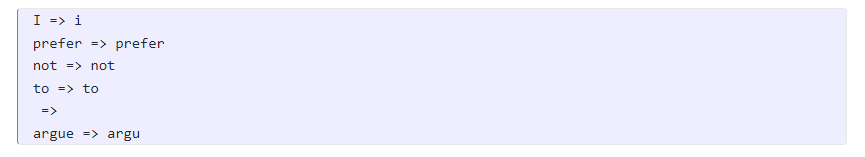

# Errors in Stemming

There are mainly two errors in stemming:  
1) Overstemming  
2) Understemming  
Overstemming occurs when two words are stemmed from the same root that are of different stems.  
Under-stemming occurs when two words are stemmed from the same root that is not of different stems.

# Applications of stemming are:

Stemming is used in information retrieval systems like search engines.  
It is used to determine domain vocabularies in domain analysis.  
Stemming is desirable as it may reduce redundancy as most of the time the word stem and their inflected/derived words mean the same.

# Nltk wordnet

Nltk wordnet is an English lexical database (dictionary) built primarily for NLP. Synset is a specific type of simple interface used in NLTK that allows users to search WordNet for words. Synset examples are collections of words that are synonymous and express the same idea.

```python
st = nltk.PorterStemmer()
def stemming_on_text(data):
    text = [st.stem(word) for word in data]
    return data
joinedtweets['text']= joinedtweets['text'].apply(lambda x: stemming_on_text(x))
joinedtweets['text'].head()
```

```
800000             [love, healthuandpets, u, guys, r, best]
800001    [im, meeting, one, besties, tonight, cant, wai...
800002    [darealsunisakim, thanks, twitter, add, sunisa...
800003    [sick, really, cheap, hurts, much, eat, real, ...
800004                    [lovesbrooklyn, effect, everyone]
Name: text, dtype: object
```

# Wordnet Lemmatizer

Wordnet is a publicly available lexical database of over 200 languages that provides semantic relationships between its words. It is one of the earliest and most commonly used lemmatizer technique.

It is present in the nltk library in python.  
Wordnet links words into semantic relations. ( eg. synonyms )  
It groups synonyms in the form of synsets.  
synsets : a group of data elements that are semantically equivalent.

```python
nltk.download('wordnet')
nltk.download('omw-1.4')
from nltk import WordNetLemmatizer
```

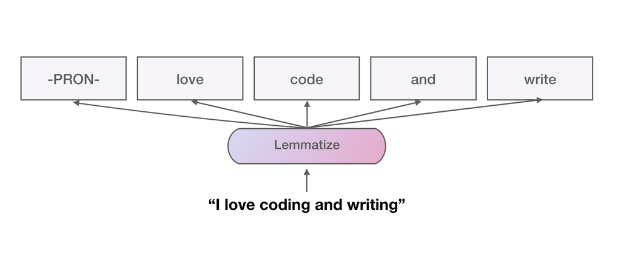

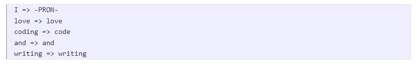

Lemmatization is the process where we take individual tokens from a sentence and we try to reduce them to their base form. The process that makes this possible is having a vocabulary and performing morphological analysis to remove inflectional endings. The output of the lemmatization process (as shown in the figure above) is the lemma or the base form of the word. For instance, a lemmatization process reduces the inflections, "am", "are", and "is", to the base form, "be". Take a look at the figure above for a full example and try to understand what it's doing

```python
lm = WordNetLemmatizer()
def lemmatizer_on_text(data):
    text = [lm.lemmatize(word) for word in data]
    return data
joinedtweets['text'] = joinedtweets['text'].apply(lambda x: lemmatizer_on_text(x))
joinedtweets['text'].head()
```

```
800000             [love, healthuandpets, u, guys, r, best]
800001    [im, meeting, one, besties, tonight, cant, wai...
800002    [darealsunisakim, thanks, twitter, add, sunisa...
800003    [sick, really, cheap, hurts, much, eat, real, ...
800004                    [lovesbrooklyn, effect, everyone]
Name: text, dtype: object
```

```python
joinedtweets.groupby('target').text.count()
```

```
target
0    20000
1    20000
Name: text, dtype: int64
```

```python
X=data.text
y=data.target
```

```python
X.shape,y.shape
```

```
((1600000,), (1600000,))
```

# Plotting Word Cloud for words in negative tweets

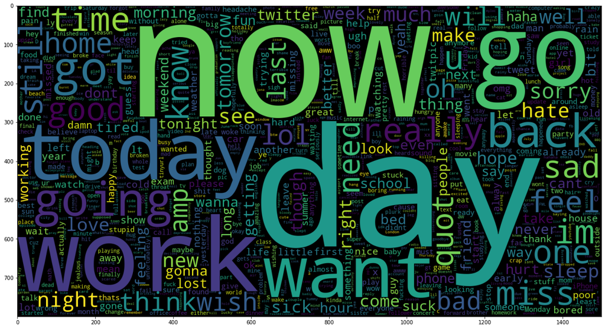

```python
data_neg = data['text'][:800000]
plt.figure(figsize = (20,20))
wc = WordCloud(max_words = 1000 , width = 1500 , height = 800,
               collocations=False).generate(" ".join(data_neg))
plt.imshow(wc)
```

# Plotting Word Cloud for words in positive tweets

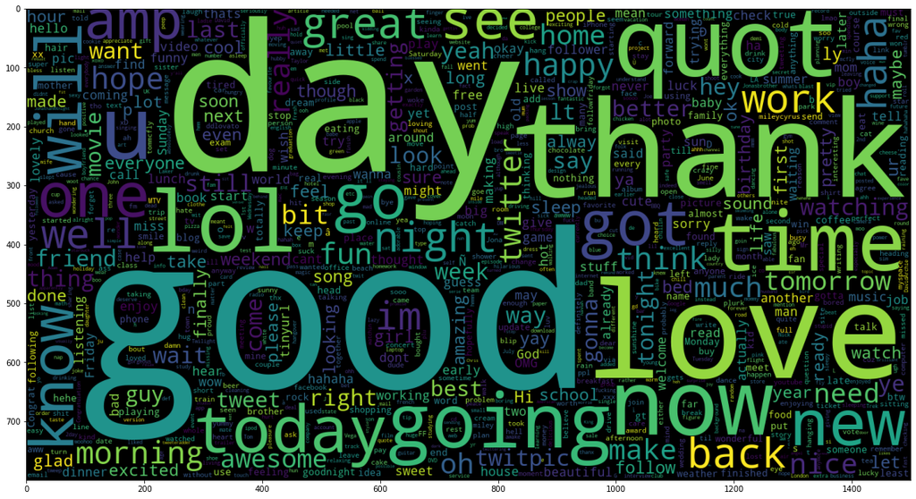

```python
data_pos = data['text'][800000:]
wc = WordCloud(max_words = 1000 , width = 1500 , height = 800,
              collocations=False).generate(" ".join(data_pos))
plt.figure(figsize = (20,20))
plt.imshow(wc)
```

# Training, Validation, and Test Sets

Splitting your dataset is essential for an unbiased evaluation of prediction performance. In most cases, it’s enough to split your dataset randomly into three subsets:

# Training Set:

The training set is applied to train, or fit, your model. For example, you use the training set to find the optimal weights, or coefficients, for linear regression, logistic regression, or neural networks.

# Validation Set:

The validation set is used for unbiased model evaluation during hyperparameter tuning. For example, when you want to find the optimal number of neurons in a neural network or the best kernel for a support vector machine, you experiment with different values. For each considered setting of hyperparameters, you fit the model with the training set and assess its performance with the validation set.

# Test Set:

The test set is needed for an unbiased evaluation of the final model. You shouldn’t use it for fitting or validation.

Here we split the dataset in 95% Training set and 5% Test set  
X_train shape = (1520000,)  
X_test shape = (80000,)

```python
 X_train, X_test, y_train, y_test = train_test_split(X,y,test_size = 0.05, random_state = 42)
```

```python
X_train.shape
```

```
(1520000,)
```

# TfidfVectorizer

The term tf–idf stands for term frequency–inverse document frequency. It is a mathematical statistic that is planned to reflect how significant a word is to a record in a collection or corpus. The tf–idf esteem builds proportionally to the number of times a word shows up in the document. It is offset by the quantity of documents in the corpus that contain the word, which helps to adjust for the fact that a few words show up more often when all is said and done.  
Term Frequency (tf)- It gives us the recurrence of the word in each report in the corpus. It is the proportion of the number of times the word shows up in a report contrasted with the all-out the number of words in that record. It increments as the quantity of events of that word inside the record increments.  
Inverse Data Frequency (idf)- It is used to figure out the heaviness of uncommon words over all reports in the corpus. The words that occur seldom in the corpus have a high IDF score.  
Inverse document frequency looks at how common (or uncommon) a word is amongst the corpus. IDF is calculated as follows where t is the term (word) we are looking to measure the commonness of and N is the number of documents (d) in the corpus (D).. The denominator is simply the number of documents in which the term, t, appears in.

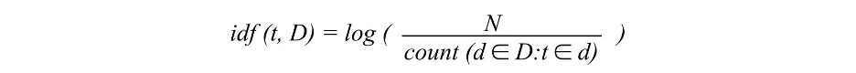

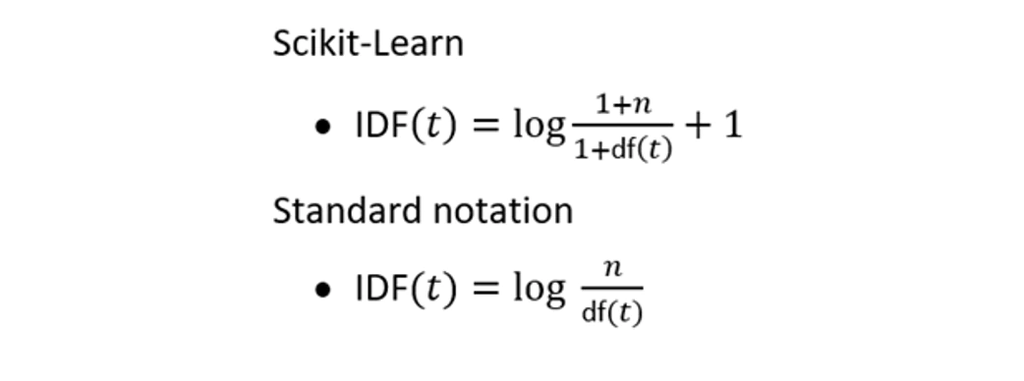

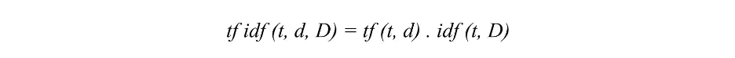

# Example

A = “The car is driven on the road”; B = “The truck is driven on the highway”

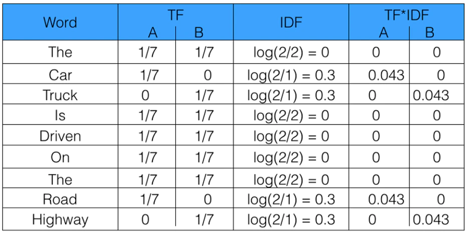

```python
vectoriser = TfidfVectorizer(ngram_range=(1,2), max_features=500000)
vectoriser.fit(X_train)
print('No. of feature_words: ', len(vectoriser.get_feature_names()))
```

```
No. of feature_words:  500000
```

```python
X_train = vectoriser.transform(X_train)
X_test  = vectoriser.transform(X_test)
```

# Function for Predicting values

1) predicting values from test set  
2) plotting evaluation matrix  
3) Plotting comfusion matrix

```python
def model_Evaluate(model):
  # Predict values for Test dataset
  y_pred = model.predict(X_test)
  # Print the evaluation metrics for the dataset.
  print(classification_report(y_test, y_pred))
  # Compute and plot the Confusion matrix
  cf_matrix = confusion_matrix(y_test, y_pred)
  categories = ['Negative','Positive']
  group_names = ['True Neg','False Pos', 'False Neg','True Pos']
  group_percentages = ['{0:.2%}'.format(value) for value in cf_matrix.flatten() / np.sum(cf_matrix)]
  labels = [f'{v1}n{v2}' for v1, v2 in zip(group_names,group_percentages)]
  labels = np.asarray(labels).reshape(2,2)
  sns.heatmap(cf_matrix, annot = labels, cmap = 'Blues',fmt = '',
  xticklabels = categories, yticklabels = categories)
  plt.xlabel("Predicted values", fontdict = {'size':14}, labelpad = 10)
  plt.ylabel("Actual values" , fontdict = {'size':14}, labelpad = 10)
  plt.title ("Confusion Matrix", fontdict = {'size':18}, pad = 20)
```